# 智商遗传的平均回归效应

以下的代码被运行于装在 *优麒麟 (Ubuntu Kylin) 19.10 64 位* 的 *SageMath 8.9*。

## 遗传模型

很多表型，如身高，如智商，的遗传都是多基因的，而且大多的差都是线性可加的，基因互相之间的效应量与线性可加的效应量相比是很小的。

根据此，我们构建一个简化的遗传模型。假设有 $n$ 互相独立的影响智商的基因，我们也假设我们关注的特征的每一个基因的表达都是显性的，即只要分别来自父母的俩等位基因有一个是显性的，就会有正向的特征表型效应。所以如果婴儿在某一个基因是 Aa 或 aA 或 AA 都会有同样程度的正向效应。同样，我们也假设每个基因的正向效应量都是同等的。可以把每个基因视为随机变量，正的时候是 $1$，负的时候是 $0$。

### 基因互换

每个基因都是双倍体，一个来自精子，另一个来自卵子，俩单倍细胞。这些性细胞来自减数分裂，在其过程中，常染色体中的每一个双倍体基因会在染色体互换中随机从两个选一个。我们为了简单会忽略掉性染色体对该特征的效应。

我们将这些互相独立，另一角度就是父母之间没有协差方，将$p$为正的概率，从这个不难算出胚胎的任意基因有正向影响的概率为 $$ u := 1 - (1-p)^2 = p(2-p) $$ 一个概率为 $u$ 的二直随机变量的差方是 $$Var(X_i) = u(1-u)$$

通过中心极限定理，我们得以所有基因的$u$的平均的差方为 $$ Var\left(\frac{\sum X_i}{n}\right) = \frac{1}{n^2}\cdot nu(1-u) $$ 并接近于正太分部，则若 $Z$ 为标准差，正向基因的数量为 $$ f(Z) = u + Z\sqrt{\frac{u(1-u)}{n}} $$

我们把 $u$ 叫做**正基因概率**。

```python
var('p,u,Z,Z1,Z2,n')
u = p*(2-p)
f = u+Z*sqrt(u*(1-u)/n)
```

我们再设 $Z_1, Z_2$ 为父母的标准差，将其代进 $f$ 得以父母的正基因概率。

```python
r = f.subs(Z == Z1)
s = f.subs(Z == Z2)
```

以下我们设 $q$ 为当一个基因是正时，他为显性纯合子的概率。

```python
q = p/(p+2*(1-p))
```

又计算一下胚胎的正基因概率。

```python
p_child = r*s*(q + (1-q)*(0.5+0.5*(q+0.5*(1-q)))) + (r*(1-s)+s*(1-r))*(q + 0.5*(1-q))
```

算出胚胎的 Z 分数或标准差

```python
z_offspring = (p_child - u) / sqrt(u*(1-u)/n)
```

设 $n = 10^4，p = 0.5$，看看俩三个标准差高于平均（大约千人之一）的父母的孩子的期望 Z 分数是多少。

```python
z_offspring.subs(Z1=3,Z2=3,p=0.5,n=10^4)
```

```
1.98267949192431
```

以下我们看到胚胎的标准差基本线地性回归到平均，相对于父母。

```
Graphics object consisting of 1 graphics primitive
```

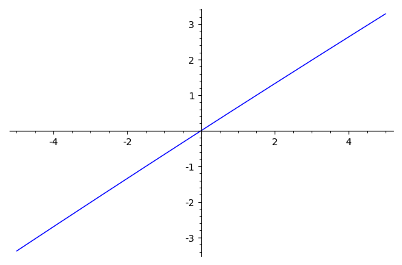

```
平均回归函数应用到智商
```

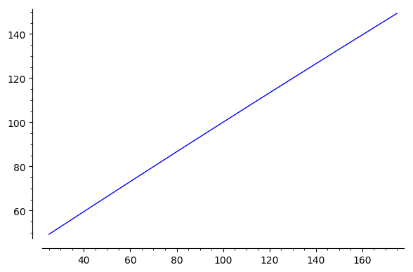

```python
# P = plot(sin, (0,10)); print(P)
def regression_function(parental_z_score):
    return z_offspring.subs(Z1=parental_z_score,Z2=parental_z_score,p=0.5,n=10^4)

P = plot(regression_function, (-5,5)); print(P)
P.show()

def iq_regression(parental_iq):
    parental_z_score = (parental_iq - 100) / 15
    return 100 + 15*regression_function(parental_z_score)

print("平均回归函数应用到智商")
iq_regression_plot = plot(iq_regression, (25, 175))
iq_regression_plot.show()
```

回归因子为

```
在 Z=1 的平均回归因子： 0.664742
在 Z=-1 的平均回归因子： 0.668591
```

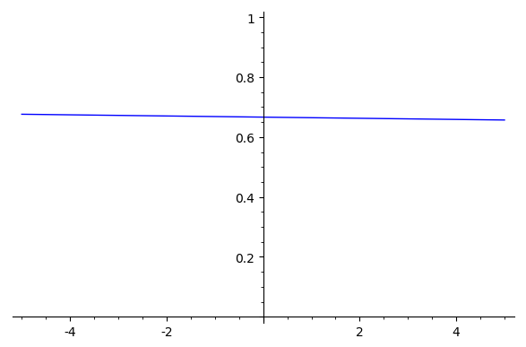

```
Regression coefficient very close to 0: 0.666666
```

```python
print("在 Z=1 的平均回归因子： %f" % (z_offspring.subs(Z1=1,Z2=1,p=0.5,n=10^4) / 1))
print("在 Z=-1 的平均回归因子： %f" % (z_offspring.subs(Z1=-1,Z2=-1,p=0.5,n=10^4) / -1))

# P = plot(sin, (0,10)); print(P)
def regression_factor(parental_z_score):
    return z_offspring.subs(Z1=parental_z_score,Z2=parental_z_score,p=0.5,n=10^4) / parental_z_score

P = plot(regression_factor, (-5,5))
P.show(ymin=0, ymax=1)

epsilon = 10^-4
regression_coeff = z_offspring.subs(Z1=epsilon,Z2=epsilon,p=0.5,n=10^4) / epsilon
print("Regression coefficient very close to 0: %f" % regression_coeff)
```

```python
mu_prob = u.subs(p=0.5)
print("正基因概率平均：%f" % mu_prob)
sigma_prob = sqrt(u*(1-u)/n).subs(p=0.5, n=10^4)
print("正基因概率标准差：%f" % sigma_prob)
```

```
正基因概率平均： 0.750000
正基因概率标准差 0.004330
```

```python
distribution = RealDistribution('gaussian', 1)

def get_normal_values(mu, sigma):
    return lambda x: distribution.distribution_function((x-mu)/sigma)

def get_normal_values_regressed(mu, sigma):
    return lambda x: distribution.distribution_function(regression_coeff*(x-mu)/sigma)
```

```python
iq_pdf = lambda x: distribution.distribution_function((x-100)/15)
iq_regressed_pdf = lambda x: distribution.distribution_function(regression_coeff*(x-100)/15)
prob_pdf = lambda x: distribution.distribution_function((x-mu_prob)/sigma_prob)
prob_regressed_pdf = lambda x: distribution.distribution_function(regression_coeff*(x-mu_prob)/sigma_prob)
```

```
正基因概率及其回归概率密度函数
```

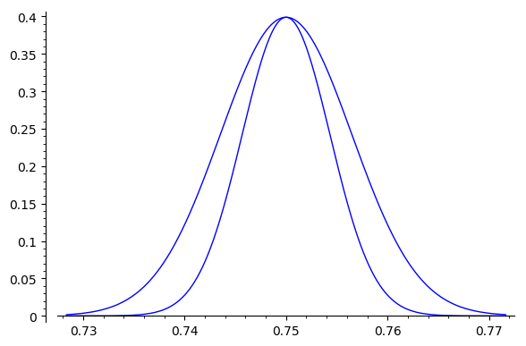

```
智商及其回归概率密度函数
```

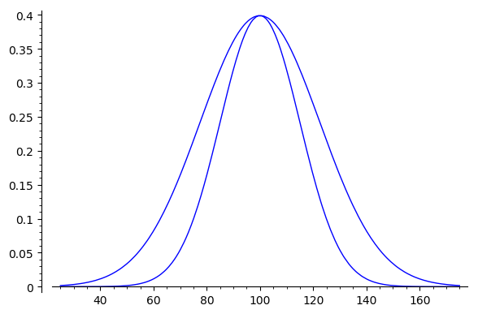

```python
prob_plot = plot(prob_pdf, (mu_prob - 5*sigma_prob, mu_prob + 5*sigma_prob))
prob_regressed_plot = plot(prob_regressed_pdf, (mu_prob - 5*sigma_prob, mu_prob + 5*sigma_prob))

print("正基因概率及其回归概率密度函数")
show(prob_plot+prob_regressed_plot)

print("智商及其回归概率密度函数")
iq_plot = plot(iq_pdf, (25, 175))
iq_regressed_plot = plot(iq_regressed_pdf, (25, 175))
show(iq_plot+iq_regressed_plot)
```

## 结论

我们可以从粗鲁知觉得知为什么会有平均回归的现象。因为即使幸运的胚胎得到比父母远远更高的智商，或更高的显性纯合子和杂合子的比例，在其中保证给下一代正向智商作用的显性纯合子的比例依然同样受限，至少在我们的模型里，即在我们模型里我们假设在下一代无论如何显性纯合子和杂合子的比例分部保持一致。

如果问反一个方向，那隐性纯合子如果更多，那隐性纯合子在下一代变成杂合子的期望值自然会更高，同样杂合子因为更少退化到隐性纯合子的可能性也更小。

一个非常聪明的人比普通人的对智商不利的隐性纯合子要少不少。非常聪明的人如果家族大多都非常聪明，那很可能显性纯合子和显性杂合子的比例（以上为 $q$）高于其一般比例，使得他的孩子的智商平均回归的程度会比大部分跟他差不多聪明的人的智商平均回归的程度要小，当然，平均回归多少和孩子的期望智商很多也要看他的配偶的智商基因分部。

少数智商精英如果长期内婚度高（比如分支于古闪米特人或阿拉伯人的犹太人或印度种性制度的波罗门），会导致 $q$ 的增长，即回归到更高的精英子群体的平均智商。

进化选择如何导致的 $q$ 的改变的问题，希望将来更细致地量化地探索。